# Tutorial 06 — Antibiotic PK/PD

**Prerequisites:** Tutorials 01–05

Phage therapy is most effective when combined with antibiotics: phage eradicate the bulk of replicating bacteria, while antibiotics reach the compartments that phage cannot — dormant populations and deep tissues. This tutorial introduces antibiotic pharmacokinetics and pharmacodynamics through the `with_antibiotic()` builder API.

**What you will learn**

1. Two-compartment antibiotic PK (`k_elim`, `k12`, `k21`, `Vc`)
2. Hill-equation PD (`emax`, `ec50`, `hill`) and the `plot_pk` visualisation
3. Bacteriostatic vs bactericidal effects
4. Per-strain resistance — antibiotic emax/ec50 arrays
5. Dormant-cell activity (`emax_dormant`, `ec50_dormant`)
6. Clinical dosing regimens via `DoseEvent`
7. Inoculum effect — density-dependent EC50 and phage–antibiotic synergy (`inoculum_effect_constant`)

## 1 Imports

```python
import numpy as np
import matplotlib.pyplot as plt

from pbisim import ModelBuilder, PBIModel, solve_ode, DoseEvent, DoseSchedule
from pbisim.analysis.single import plot_pk

T_END = 48.0   # h

BASE_B = (
    ModelBuilder(n_bacteria=1, n_phages=0)   # bacteria only — isolate antibiotic effect
    .with_growth_rates(1.0, bacteria_to_resource_ratio=1e9)
    .with_nutrient(monod_constant=0.3, recycle_fraction=0.0)
)
B0 = np.array([1e8])   # dense inoculum so antibiotic effect is clearly visible
```

## 2 The `with_antibiotic()` API

`with_antibiotic()` registers one drug at a time. Multiple calls accumulate drugs into a list; `build()` assembles `PKConfig` and `PDConfig` automatically.

**PK parameters (shared across strains):**

- `k_elim` (h⁻¹): first-order elimination from the central (blood) compartment
- `Vc` (L): central compartment volume — converts drug amount to concentration
- `k12`, `k21` (h⁻¹): distribution to and from peripheral (tissue) compartment

**PD parameters (per strain):**

- `emax` (h⁻¹): maximum bactericidal kill rate
- `ec50`: drug concentration producing 50% of maximum effect (same units as Vc-derived concentration)
- `hill`: Hill coefficient — steepness of the concentration–response curve

**Biological meaning of the Hill equation:** `kill_rate(C) = emax · C^hill / (ec50^hill + C^hill)`

- `emax` is the "ceiling" kill rate — set to the maximum biologically achievable
- `ec50` ≈ MIC (minimum inhibitory concentration)
- `hill` > 1: "all-or-nothing" kill once concentration crosses MIC; `hill` = 1: gradual, proportional response (most common)

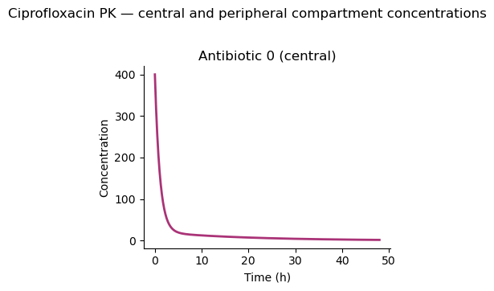

```
Peak central concentration: 26.7 mg/L  (at 2400×ec50 = 25.0 mg/L)
Kill rate at peak: emax × C/(ec50+C) = 5 × 26.7/(27.2) ≈ 4.91 h⁻¹
```

```python
# Ciprofloxacin-like parameters (concentration-dependent fluoroquinolone)
cfg_abx = (
    BASE_B
    .with_antibiotic(
        "ciprofloxacin",
        k_elim = 0.5,    # h⁻¹  — half-life ≈ 1.4 h (IV ciprofloxacin)
        Vc     = 15.0,   # L    — volume of distribution ≈ 15 L (IV)
        k12    = 0.4,    # h⁻¹  — distribution to peripheral tissues
        k21    = 0.1,    # h⁻¹  — redistribution back to blood
        emax   = 5.0,    # h⁻¹  — maximum kill rate
        ec50   = 0.5,    # mg/L — half-maximal effect concentration ≈ MIC
        hill   = 1.0,    # — linear concentration-response
    )
    .build()
)

# 400 mg IV dose (typical ciprofloxacin dose) → Ac_0 = 400 mg in Vc=15L → Cc_0 = 26.7 mg/L
dose_iv = DoseSchedule([DoseEvent(time=0, amount=400.0, target="antibiotic", index=0)])

cfg_abx_dosed = (
    BASE_B
    .with_antibiotic("ciprofloxacin",
                     k_elim=0.5, Vc=15.0, k12=0.4, k21=0.1,
                     emax=5.0, ec50=0.5, hill=1.0)
    .with_dose_schedule(dose_iv)
    .build()
)

res_abx = solve_ode(
    PBIModel(cfg_abx_dosed, initial_B=B0, initial_P=np.zeros(0), initial_S=1.0),
    t_end=T_END, dt=0.25,
)

fig, axes = plot_pk(res_abx)
fig.suptitle("Ciprofloxacin PK — central and peripheral compartment concentrations",
             y=1.02)
plt.tight_layout()
plt.show()

Cc_peak = res_abx.get("Ac0")[0] / 15.0
print(f"Peak central concentration: {Cc_peak:.1f} mg/L  (at {50*T_END:.0f}×ec50 = {50*0.5:.1f} mg/L)")
print(f"Kill rate at peak: emax × C/(ec50+C) = 5 × {Cc_peak:.1f}/({0.5+Cc_peak:.1f}) ≈ {5*Cc_peak/(0.5+Cc_peak):.2f} h⁻¹")
```

## 3 Bactericidal effect — comparing emax and dosing frequency

A **concentration-dependent** antibiotic like ciprofloxacin kills most effectively when peak concentrations are high (even briefly). Key insight: the ratio `Cmax / MIC` predicts outcome better than time above MIC.

Below we compare:

- A single 400 mg dose (high peak, short duration)
- 200 mg given twice (lower peak, more sustained)
- No antibiotic (control)

Even though the total dose is the same, the single 400 mg dose achieves a higher peak concentration and faster initial killing.

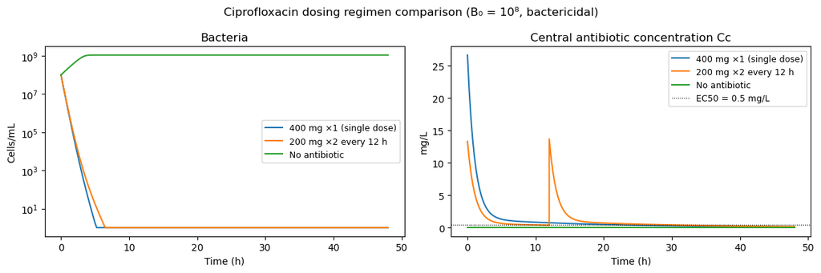

```python
def _run_abx(schedules_mg, label_list, t_end=T_END):
    results = []
    for events, label in zip(schedules_mg, label_list):
        dose_sched = DoseSchedule([
            DoseEvent(time=t, amount=mg, target="antibiotic", index=0)
            for t, mg in events
        ])
        cfg = (
            BASE_B
            .with_antibiotic("cipro", k_elim=0.5, Vc=15.0, k12=0.4, k21=0.1,
                             emax=5.0, ec50=0.5, hill=1.0)
            .with_dose_schedule(dose_sched)
            .build()
        )
        res = solve_ode(PBIModel(cfg, initial_B=B0,
                                 initial_P=np.zeros(0), initial_S=1.0),
                        t_end=t_end, dt=0.25)
        results.append((res, label))
    return results

regimens = [
    ([(0, 400)],               "400 mg ×1 (single dose)"),
    ([(0, 200), (12, 200)],    "200 mg ×2 every 12 h"),
    ([],                       "No antibiotic"),
]
results_abx = _run_abx(
    [r[0] for r in regimens],
    [r[1] for r in regimens],
)

fig, axes = plt.subplots(1, 2, figsize=(12, 4))
for res, label in results_abx:
    axes[0].semilogy(res.time, np.maximum(res.get("B0"), 1), label=label)
    Cc = res.get("Ac0") / 15.0
    axes[1].plot(res.time, np.maximum(Cc, 0), label=label)

axes[0].set(xlabel="Time (h)", ylabel="Cells/mL", title="Bacteria")
axes[1].set(xlabel="Time (h)", ylabel="mg/L",
            title="Central antibiotic concentration Cc")
axes[1].axhline(0.5, ls=":", color="k", lw=0.8, label="EC50 = 0.5 mg/L")
for ax in axes: ax.legend(fontsize=9)
plt.suptitle("Ciprofloxacin dosing regimen comparison (B₀ = 10⁸, bactericidal)")
plt.tight_layout()
plt.show()
```

## 4 Bacteriostatic effect

Some antibiotics (tetracyclines, macrolides, chloramphenicol) primarily **inhibit growth** rather than kill directly. In pbisim, `bacteriostatic_emax` multiplies the growth fraction `frac`:

`growth_effective = μ · frac · (1 − bacteriostatic_emax · C^hill / (ec50^hill + C^hill))`

At full bacteriostatic effect (`bacteriostatic_emax = 1.0`), growth is completely halted but bacteria remain viable. Combined bacteriostatic + bactericidal is common for drugs like doxycycline.

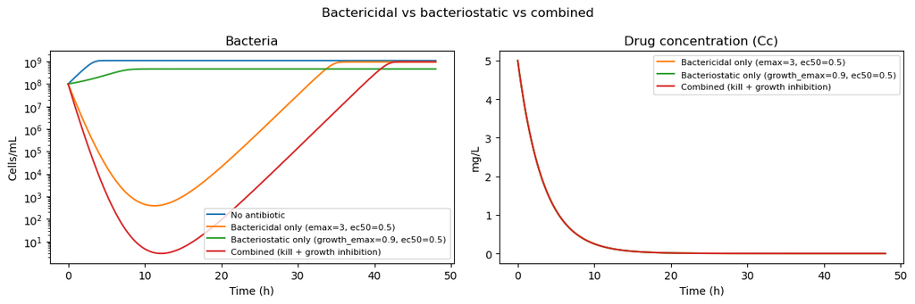

```python
fig, axes = plt.subplots(1, 2, figsize=(12, 4))

for (mode, color, label) in [
    ("none",   "C0", "No antibiotic"),
    ("bact_i", "C1", "Bactericidal only (emax=3, ec50=0.5)"),
    ("bact_s", "C2", "Bacteriostatic only (growth_emax=0.9, ec50=0.5)"),
    ("combo",  "C3", "Combined (kill + growth inhibition)"),
]:
    if mode == "none":
        cfg_ = BASE_B.build()
    elif mode == "bact_i":
        cfg_ = (BASE_B.with_antibiotic("drug", k_elim=0.3, Vc=10.0,
                    emax=3.0, ec50=0.5, hill=1.0)
                .with_dose_schedule(DoseSchedule([
                    DoseEvent(time=0, amount=50.0, target="antibiotic", index=0)]))
                .build())
    elif mode == "bact_s":
        cfg_ = (BASE_B.with_antibiotic("drug", k_elim=0.3, Vc=10.0,
                    emax=0.0, ec50=0.5,
                    bacteriostatic_emax=0.9, bacteriostatic_ec50=0.5)
                .with_dose_schedule(DoseSchedule([
                    DoseEvent(time=0, amount=50.0, target="antibiotic", index=0)]))
                .build())
    else:  # combo
        cfg_ = (BASE_B.with_antibiotic("drug", k_elim=0.3, Vc=10.0,
                    emax=3.0, ec50=0.5,
                    bacteriostatic_emax=0.9, bacteriostatic_ec50=0.5)
                .with_dose_schedule(DoseSchedule([
                    DoseEvent(time=0, amount=50.0, target="antibiotic", index=0)]))
                .build())
    res_ = solve_ode(PBIModel(cfg_, initial_B=B0, initial_P=np.zeros(0), initial_S=1.0),
                     t_end=T_END, dt=0.25)
    axes[0].semilogy(res_.time, np.maximum(res_.get("B0"), 1), color=color, label=label)
    if mode != "none":
        axes[1].plot(res_.time, np.maximum(res_.get("Ac0") / 10.0, 0),
                     color=color, label=label)

axes[0].set(xlabel="Time (h)", ylabel="Cells/mL", title="Bacteria")
axes[1].set(xlabel="Time (h)", ylabel="mg/L",
            title="Drug concentration (Cc)")
for ax in axes: ax.legend(fontsize=8)
plt.suptitle("Bactericidal vs bacteriostatic vs combined")
plt.tight_layout()
plt.show()
```

## 5 Effect compartment — onset delay and postantibiotic effect

In some in vitro time-kill assays, bacterial growth tracks the antibiotic-free control for 2–3 h before diverging, even though the medium concentration is already at its final value. This **onset delay** reflects the time needed for the drug to equilibrate from the medium into its intracellular target site.

The **effect compartment** (biophase) model captures this with one extra parameter:

```
dAe/dt = ke0 · (Cc − Ae)      Cc = central concentration
```

PD functions act on `Ae` (effect compartment) instead of `Cc` (central). At steady state `Ae = Cc`, but the equilibration half-life `t½ = ln(2)/ke0` introduces:

- **Onset delay** — at t=0, `Ae=0` even when `Cc` is already at its full value; killing rises as `Ae` equilibrates (constant-concentration TKA scenario).
- **Postantibiotic effect (PAE)** — when dosing stops and `Cc` drops, `Ae` decays slowly, sustaining bacterial suppression for `~1/ke0` h.

Set `ke0` via `.with_antibiotic(ke0=...)`. `None` (default) gives direct central-to-effect linkage (no delay, no PAE).

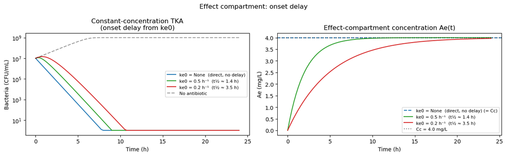

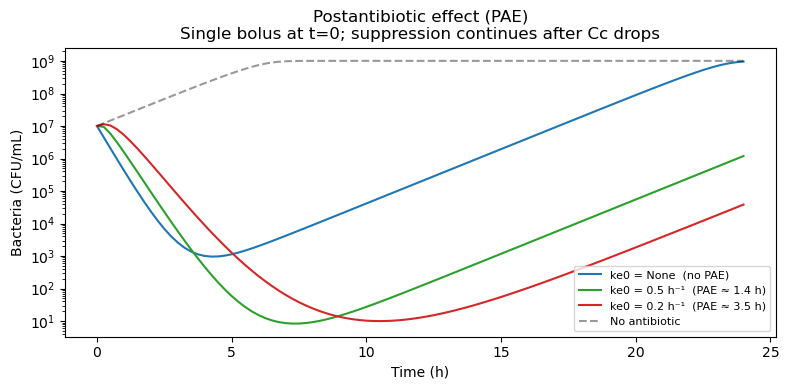

```python
# ── Constant-concentration in vitro TKA ──────────────────────────────────────
# k_elim=0: antibiotic is not eliminated — medium concentration held constant.
# initial_Ac pre-loads the central compartment to the target concentration.
# Ae starts at 0 regardless, so only ke0 > 0 produces an onset delay.

CONC = 4.0    # mg/L — held constant throughout
B0_tka = np.array([1e7])  # initial inoculum (CFU/mL)

fig, axes = plt.subplots(1, 2, figsize=(13, 4))

for ke0, color, label in [
    (None, 'C0', 'ke0 = None  (direct, no delay)'),
    (0.5,  'C2', 'ke0 = 0.5 h⁻¹  (t½ ≈ 1.4 h)'),
    (0.2,  'C3', 'ke0 = 0.2 h⁻¹  (t½ ≈ 3.5 h)'),
]:
    cfg = (
        ModelBuilder(n_bacteria=1, n_phages=0)
        .with_growth_rates(1.0, bacteria_to_resource_ratio=1e9)
        .with_nutrient(carrying_capacity=1e9, monod_constant=0.3)
        .with_antibiotic(
            'abx',
            k_elim = 0.0,          # constant concentration — no elimination
            Vc     = 1.0,
            ke0    = ke0,
            emax   = 3.0,          # max kill rate (h⁻¹)
            ec50   = 1.0,          # EC50 (mg/L)
            hill   = 2.0,
        )
        .build()
    )
    model = PBIModel(cfg, initial_B=B0_tka, initial_P=np.zeros(0),
                     initial_Ac=np.array([CONC]))
    res = solve_ode(model, t_end=24.0, dt=0.25)

    B = res.sum_prefixes('B')
    axes[0].semilogy(res.time, np.maximum(B, 1), color=color, label=label)

    if ke0 is not None:
        Ae = res.get('Ae0')
        axes[1].plot(res.time, Ae, color=color, label=label)
    else:
        axes[1].axhline(CONC, color=color, linestyle='--', label=label + ' (= Cc)')

# Antibiotic-free control
cfg0 = (
    ModelBuilder(n_bacteria=1, n_phages=0)
    .with_growth_rates(1.0, bacteria_to_resource_ratio=1e9)
    .with_nutrient(carrying_capacity=1e9, monod_constant=0.3)
    .build()
)
res0 = solve_ode(PBIModel(cfg0, initial_B=B0_tka, initial_P=np.zeros(0)),
                 t_end=24.0, dt=0.25)
axes[0].semilogy(res0.time, np.maximum(res0.sum_prefixes('B'), 1),
                 'k--', alpha=0.4, label='No antibiotic')
axes[0].set(xlabel='Time (h)', ylabel='Bacteria (CFU/mL)',
            title='Constant-concentration TKA\n(onset delay from ke0)')
axes[0].legend(fontsize=8)
axes[1].axhline(CONC, color='k', linestyle=':', alpha=0.5, label=f'Cc = {CONC} mg/L')
axes[1].set(xlabel='Time (h)', ylabel='Ae (mg/L)',
            title='Effect-compartment concentration Ae(t)')
axes[1].legend(fontsize=8)
plt.suptitle('Effect compartment: onset delay')
plt.tight_layout()
plt.show()

# ── Postantibiotic effect (PAE) — single bolus, drug washes out ──────────────
fig2, ax2 = plt.subplots(figsize=(8, 4))

for ke0, color, label in [
    (None, 'C0', 'ke0 = None  (no PAE)'),
    (0.5,  'C2', 'ke0 = 0.5 h⁻¹  (PAE ≈ 1.4 h)'),
    (0.2,  'C3', 'ke0 = 0.2 h⁻¹  (PAE ≈ 3.5 h)'),
]:
    cfg = (
        ModelBuilder(n_bacteria=1, n_phages=0)
        .with_growth_rates(1.0, bacteria_to_resource_ratio=1e9)
        .with_nutrient(carrying_capacity=1e9, monod_constant=0.3)
        .with_antibiotic(
            'abx',
            k_elim = 0.7,          # eliminated: half-life ≈ 1 h
            Vc     = 1.0,
            ke0    = ke0,
            emax   = 4.0,
            ec50   = 1.0,
            hill   = 2.0,
        )
        .with_dose_schedule(DoseSchedule([
            DoseEvent(time=0.0, amount=10.0, target='antibiotic', index=0),
        ]))
        .build()
    )
    res = solve_ode(PBIModel(cfg, initial_B=B0_tka, initial_P=np.zeros(0)),
                   t_end=24.0, dt=0.25)
    ax2.semilogy(res.time, np.maximum(res.sum_prefixes('B'), 1),
                color=color, label=label)

ax2.semilogy(res0.time, np.maximum(res0.sum_prefixes('B'), 1),
             'k--', alpha=0.4, label='No antibiotic')
ax2.set(xlabel='Time (h)', ylabel='Bacteria (CFU/mL)',
        title='Postantibiotic effect (PAE)\n'
              'Single bolus at t=0; suppression continues after Cc drops')
ax2.legend(fontsize=8)
plt.tight_layout()
plt.show()
```

## 6 Per-strain resistance and dormant-cell activity

In multi-strain models, each strain can have its own `emax` and `ec50`. Resistant strains have a higher EC50 (shifted dose–response curve) or lower Emax (reduced maximum kill).

Dormant bacteria are notoriously tolerant to many antibiotics — they are metabolically inactive and lack the targets that antibiotics exploit (cell wall synthesis, ribosome activity, DNA gyrase).

`emax_dormant` and `ec50_dormant` set independent PD parameters for the dormant compartment (D). If not specified, dormant bacteria are unaffected.

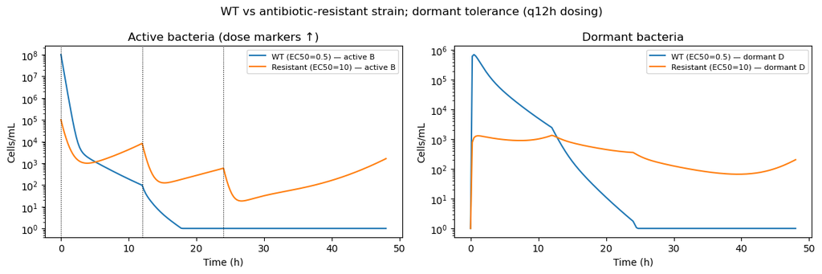

```
Key takeaway: resistant mutants survive and eventually dominate;
dormant bacteria in both strains are partially tolerant.
```

```python
cfg_resist = (
    ModelBuilder(n_bacteria=2, n_phages=0, n_depth=2)   # WT + resistant
    .with_growth_rates([1.0, 0.95], bacteria_to_resource_ratio=1e9)  # slight cost
    .with_dormancy(dormancy_rate=0.2, resuscitation_rate=0.1,
                   dormancy_signal="nutrient", resuscitation_signal="nutrient")
    .with_nutrient(monod_constant=0.3, recycle_fraction=0.0)
    # WT: sensitive; resistant mutant: 20× higher EC50
    .with_antibiotic("cipro", k_elim=0.5, Vc=15.0, k12=0.4, k21=0.1,
                     emax   = [5.0, 5.0],          # same Emax
                     ec50   = [0.5, 10.0],          # resistant: EC50 = 10 mg/L
                     hill   = 1.0,
                     emax_dormant = [1.0, 0.5],     # dormant somewhat tolerant
                     ec50_dormant = [2.0, 20.0])    # dormant: 4× higher EC50
    .with_dose_schedule(DoseSchedule([
        DoseEvent(time=0,  amount=400.0, target="antibiotic", index=0),
        DoseEvent(time=12, amount=400.0, target="antibiotic", index=0),
        DoseEvent(time=24, amount=400.0, target="antibiotic", index=0),
    ]))
    .build()
)

res_resist = solve_ode(
    PBIModel(cfg_resist, initial_B=np.array([1e8, 1e5]),
             initial_P=np.zeros(0), initial_S=1.0),
    t_end=48.0, dt=0.25,
)

fig, axes = plt.subplots(1, 2, figsize=(12, 4))
LABELS = ["WT (EC50=0.5)", "Resistant (EC50=10)"]
for i, label in enumerate(LABELS):
    B_act = res_resist.get(f"B{i}")
    D_tot = sum(res_resist.get(f"D{d}_{i}") for d in range(2))
    axes[0].semilogy(res_resist.time, np.maximum(B_act, 1), label=f"{label} — active B")
    axes[1].semilogy(res_resist.time, np.maximum(D_tot, 1), label=f"{label} — dormant D")

for t_dose in [0, 12, 24]:
    axes[0].axvline(t_dose, color="k", ls=":", lw=0.8)
axes[0].set(xlabel="Time (h)", ylabel="Cells/mL", title="Active bacteria (dose markers ↑)")
axes[1].set(xlabel="Time (h)", ylabel="Cells/mL", title="Dormant bacteria")
for ax in axes: ax.legend(fontsize=8)
plt.suptitle("WT vs antibiotic-resistant strain; dormant tolerance (q12h dosing)")
plt.tight_layout()
plt.show()
print("Key takeaway: resistant mutants survive and eventually dominate;")
print("dormant bacteria in both strains are partially tolerant.")
```

## 7 Inoculum effect — density-dependent antibiotic efficacy

Many antibiotics — especially β-lactams — are substantially **less effective at high bacterial density**, a phenomenon called the *inoculum effect* (IE). The underlying mechanism is saturation of the antibiotic target:

- **β-lactams / carbapenems:** high inoculum → more β-lactamase enzyme → faster drug hydrolysis before reaching individual cells.
- **Aminoglycosides / polymyxins:** receptor binding sites become saturated at high cell density; per-cell drug exposure falls.

Quantitatively, the apparent EC50 rises with bacterial density:

```
EC50_eff(B) = EC50 × (1 + Btot / K_inoc)
```

where `K_inoc` is the density at which EC50 doubles. Experimentally, EC50 can increase 10–17-fold between 10⁵ and 10⁸ CFU/mL, implying `K_inoc ~ 10⁶–10⁷` CFU/mL for β-lactams against Gram-negatives.

### Implication for phage–antibiotic synergy (PAS)

This mirrors phage–immune synergy (Tutorial 03), but is **externally controllable**: antibiotic concentration can be maintained by dosing schedule, unlike immune dynamics.

Enable with `inoculum_effect_constant=K_inoc` in `.with_antibiotic()`. `Btot = sum(B) + sum(I)` (metabolically active bacteria, which drive enzyme saturation; dormant bacteria contribute negligibly to β-lactamase secretion).

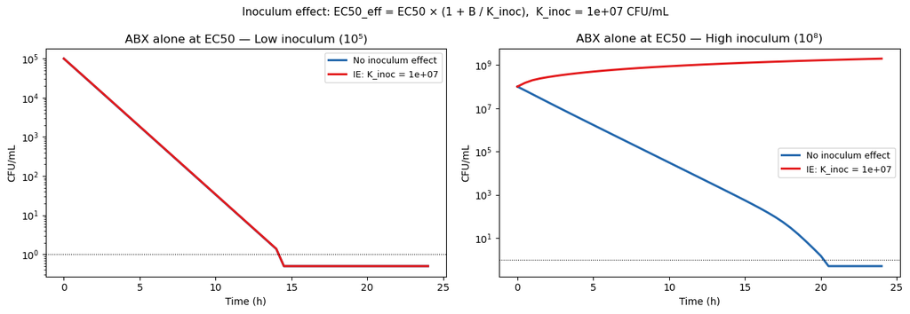

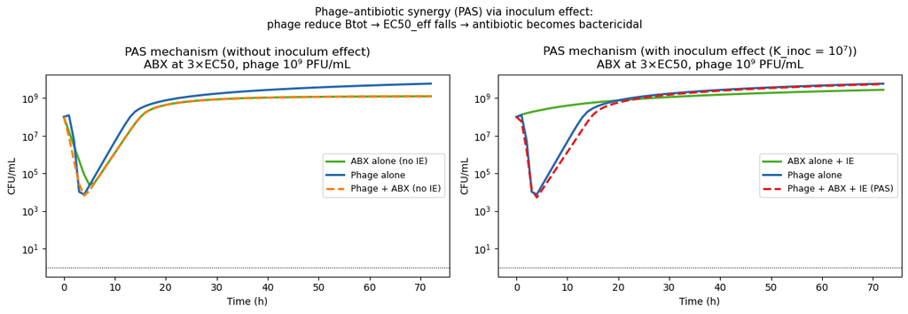

```
Final CFU/mL at 72 h (with inoculum effect):
  ABX alone + IE                          2.77e+09
```

```
  Phage alone                             5.90e+09
```

```
  Phage + ABX + IE (PAS)                  5.56e+09
```

```python
import warnings, dataclasses as _dc
from pbisim.strains import BinaryResistanceGenotypes, BacterialStrain, PhageStrain
from pbisim.pd.models import PDConfig
from pbisim.pk.models import PKConfig

# ── Shared phage-bacteria model (2-strain: susceptible + phage-resistant) ────
g, btr, Ks   = 1.8, 1e8, 0.5
beta, tau     = 50.0, 0.5
K_MPA         = 1e-9
MU, FC        = 1e-7, 0.10
DECAY_P       = 0.2

bac = BacterialStrain(
    base_growth_rate=g, bacteria_to_resource_ratio=btr,
    dormancy_rate=0.0, resuscitation_rate=1.0,
)
phi = PhageStrain(
    name="phi",
    adsorption_s=K_MPA, adsorption_r=K_MPA * 1e-4,
    adsorption_dormant_s=0.0, adsorption_dormant_r=0.0,
    burst_size_s=beta, burst_size_r=beta,
    latent_period_s=tau, latent_period_r=tau,
    latent_period_dormant_s=tau, latent_period_dormant_r=tau,
    decay_rate=DECAY_P, fitness_cost=FC, mu=MU,
)
brg = BinaryResistanceGenotypes.from_strains(phages=[phi], bacteria=bac)
base_cfg = brg.to_config(n_latent=5, n_depth=1, monod_constant=Ks, s_in=1.0, s_out=1.0)

# ── ABX parameters: β-lactam-like with strong inoculum effect ────────────────
K_INOC   = 1e7    # EC50 doubles at 10⁷ CFU/mL
EC50_ABX = 1.0    # µg/mL at low inoculum (susceptible strain)
EMAX_ABX = 4.0    # h⁻¹ max kill rate

def _make_abx_cfg(use_ie: bool, K_inoc_val: float = K_INOC):
    ie = np.array([K_inoc_val]) if use_ie else None
    pd = PDConfig(
        n_antibiotics=1,
        abx_emax=np.array([[EMAX_ABX], [EMAX_ABX * 0.05]]),
        abx_ec50=np.array([[EC50_ABX], [EC50_ABX]]),
        abx_hill=np.array([[1.0],      [1.0]]),
        inoculum_effect_constant=ie,
    )
    pk = PKConfig(
        n_antibiotics=1,
        k_elim=np.array([0.0]),
        k12=np.array([0.0]),
        k21=np.array([0.0]),
        Vc=np.array([1.0]),
    )
    return _dc.replace(base_cfg, n_antibiotics=1, pk_config=pk, pd_config=pd)

# ── Part A: Dose–response at two inocula (ABX alone, no phage) ────────────────
fig, axes = plt.subplots(1, 2, figsize=(13, 4.5))

B0_lo = np.array([1e5, 0.0])   # low inoculum — IE negligible
B0_hi = np.array([1e8, 0.0])   # high inoculum — IE significant

for B0_abx, ax, title in [(B0_lo, axes[0], 'Low inoculum (10⁵)'),
                           (B0_hi, axes[1], 'High inoculum (10⁸)')]:
    for use_ie, color, label in [(False, '#2166ac', 'No inoculum effect'),
                                  (True,  '#e31a1c', f'IE: K_inoc = {K_INOC:.0e}')]:
        cfg_a = _make_abx_cfg(use_ie)
        ev = DoseEvent(time=0, amount=EC50_ABX, target='antibiotic', index=0)
        cfg_a = _dc.replace(cfg_a, dose_schedule=DoseSchedule([ev]))
        with warnings.catch_warnings():
            warnings.simplefilter('ignore')
            res_a = solve_ode(PBIModel(cfg_a, initial_B=B0_abx, initial_P=np.zeros(1),
                                        initial_S=1.0),
                               t_end=24, dt=0.5, extinction_threshold=1.0)
        B_tot = res_a.sum_prefixes('B', 'D', 'I', 'H')
        ax.semilogy(res_a.time, np.clip(B_tot, 0.5, None), color=color, lw=2.2, label=label)

    ax.set(xlabel='Time (h)', ylabel='CFU/mL', title=f'ABX alone at EC50 — {title}')
    ax.axhline(1, ls=':', color='k', lw=0.8)
    ax.legend(fontsize=9)

plt.suptitle(
    f'Inoculum effect: EC50_eff = EC50 × (1 + B / K_inoc),  K_inoc = {K_INOC:.0e} CFU/mL',
    fontsize=11,
)
plt.tight_layout()
plt.show()

# ── Part B: Phage + ABX synergy mediated by inoculum effect ──────────────────
B0_pas = np.array([1e8, 1e2])   # high inoculum + small resistant subpop
P0_pas = np.zeros(1)
P_DOSE = 1e9     # suprainundative phage dose
ABX_Cc = 3.0     # mg/L — 3× EC50 at low inoculum; only 0.27× EC50_eff at B=10⁸

def _run_combo(phage: bool, abx: bool, use_ie: bool):
    cfg_c = _make_abx_cfg(use_ie) if abx else base_cfg
    events = []
    if abx:
        events.append(DoseEvent(time=0, amount=ABX_Cc, target='antibiotic', index=0))
    if phage:
        events.append(DoseEvent(time=0, amount=P_DOSE, target='phage', index=0))
    cfg_c = _dc.replace(cfg_c, dose_schedule=DoseSchedule(events) if events else None)
    with warnings.catch_warnings():
        warnings.simplefilter('ignore')
        return solve_ode(
            PBIModel(cfg_c, initial_B=B0_pas, initial_P=P0_pas, initial_S=1.0),
            t_end=72, dt=1.0, extinction_threshold=1.0,
        )

# (phage, abx, use_ie, color, linestyle, label)
scenarios_no_ie = [
    (False, True,  False, '#4dac26', '-',  'ABX alone (no IE)'),
    (True,  False, False, '#2166ac', '-',  'Phage alone'),
    (True,  True,  False, '#ff7f00', '--', 'Phage + ABX (no IE)'),
]
scenarios_ie = [
    (False, True,  True,  '#4dac26', '-',  'ABX alone + IE'),
    (True,  False, False, '#2166ac', '-',  'Phage alone'),
    (True,  True,  True,  '#e31a1c', '--', 'Phage + ABX + IE (PAS)'),
]

fig2, axes2 = plt.subplots(1, 2, figsize=(13, 4.5))

for ax, scenarios, title_sfx in [
    (axes2[0], scenarios_no_ie, 'without inoculum effect'),
    (axes2[1], scenarios_ie,    'with inoculum effect (K_inoc = 10⁷)'),
]:
    for ph, ab, ie, col, ls, lab in scenarios:
        res_c = _run_combo(ph, ab, ie)
        B_tot = res_c.sum_prefixes('B', 'D', 'I', 'H')
        ax.semilogy(res_c.time, np.clip(B_tot, 0.5, None),
                    color=col, lw=2.2, ls=ls, label=lab)
    ax.axhline(1, ls=':', color='k', lw=0.8)
    ax.set(xlabel='Time (h)', ylabel='CFU/mL',
           title=f'PAS mechanism ({title_sfx})\nABX at 3×EC50, phage 10⁹ PFU/mL')
    ax.legend(fontsize=9)

plt.suptitle(
    'Phage–antibiotic synergy (PAS) via inoculum effect:\n'
    'phage reduce Btot → EC50_eff falls → antibiotic becomes bactericidal',
    fontsize=11,
)
plt.tight_layout()
plt.show()

# Summary table
print("\nFinal CFU/mL at 72 h (with inoculum effect):")
for ph, ab, ie, col, ls, lab in scenarios_ie:
    r = _run_combo(ph, ab, ie)
    B = r.sum_prefixes('B', 'D', 'I', 'H')[-1]
    print(f"  {lab:<38s}  {B:.2e}")
```

## 8 Summary

| Parameter | Role | Typical values |
| --- | --- | --- |
| `k_elim` | Drug elimination from blood | 0.3–1.0 h⁻¹ |
| `Vc` | Central compartment volume | 5–30 L |
| `k12`, `k21` | Distribution to/from tissues | 0.1–0.5 h⁻¹ |
| `emax` | Maximum bactericidal kill rate | 3–10 h⁻¹ |
| `ec50` | Half-max effective concentration ≈ MIC | drug-specific |
| `hill` | Steepness of kill curve (usually 1) | 0.5–3 |
| `bacteriostatic_emax` | Max growth inhibition (0–1) | 0.5–1.0 |
| `emax_dormant` | Kill rate for dormant compartment | lower than emax |
| `ec50_dormant` | Effective concentration for dormant kill | higher than ec50 |
| `inoculum_effect_constant` | Bacterial density at which EC50 doubles (`K_inoc`) | 10⁶–10⁷ CFU/mL (β-lactams) |

**Clinical insight:** The combination of phage (target: replicating bacteria, high burst-size amplification) with an antibiotic (target: dormant tolerant bacteria, residual resistant minority) is the theoretical basis of phage- antibiotic synergy (PAS) reported in clinical case reports.

**Next tutorial:** *Dosing schedules* — building complex multi-drug, multi-time regimens with `DoseEvent` and `DoseSchedule`.